# 20200123_refine/spec_bestion_sum (UPS_10Concentrations)

```r
source('RScripts/commons_functions.R')
source('RScripts/file-utils.R')

file = list.files(path = params$input_directory, pattern = ".*\\.xlsx")[1]
all.proteins = NULL
ions.summary = NULL
proteins.summary = NULL
peptides.summary = NULL
```

# Parameters

Parameters used to generate this report :

| variable | value |
| --- | --- |
| abundance_column_regexp | ^abundance |
| flags_accession_regexp | ups=HUMAN_UPS; background=YEAS\|yeas |
| input_directory | data/UPS_10Concentrations/20200123_refine/spec_bestion_sum |
| ions_sheet_index | 5 |
| peptides_sheet_index | 7 |
| proteins_sheet_index | 4 |
| title | 20200123_refine/spec_bestion_sum (UPS_10Concentrations) |

Detected data files to process: WP4_all.xlsx

# Comparison WP4_all.xlsx

## Ions analysis

- Analysis parameters :
  - The analysed file name : **data/UPS_10Concentrations/20200123_refine/spec_bestion_sum/WP4_all.xlsx**
  - File date: **2020-01-29 08:45:21**
  - Ions sheet used : **Quantified peptide ions**
  - Proteins sheet used : **Protein sets**
  - Number of runs: **40**
  - Number of ions : **25300**

### Ions Summary

Summary of identified and quantified (fully or partially) ions, grouped by matching accessions categories (see `flags_accession_regexp` parameter).

```r
ions_summary = quantified_summary(proline.ions, params$abundance_column_regexp)
knitr::kable(ions_summary$counts)
```

| name | background | ups | unknown | total |
| --- | --- | --- | --- | --- |
| all | 24002 | 1086 | 212 | 25300 |
| quantified | 24002 | 1086 | 212 | 25300 |
| fully_quantified | 13811 | 21 | 108 | 13940 |
| partially_quantified | 10191 | 1065 | 104 | 11360 |
| missing_values | 91923 | 23595 | 1676 | 117194 |
| expected_values | 960080 | 43440 | 8480 | 1012000 |

```r
knitr::kable(ions_summary$rates)
```

| name | background | ups | unknown | total |
| --- | --- | --- | --- | --- |
| missing_value_rate | 9.574515 | 54.3163 | 19.76415 | 11.58043 |

```r
## add the file summary to the global one
ions_summary = ions_summary$counts
ions_summary$file = file
ions.summary = rbind(ions.summary, ions_summary)
```

### Ions Missing values

Number of ions matching a “background” (see `flags_accession_regexp` parameter, if “background” category is undefined, takes all ions into account) protein for which an abundance value was defined in more than *n* samples.

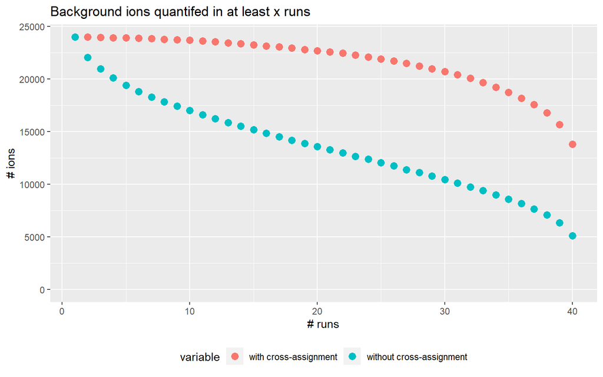

```r
ggplot(background.ions$missing, aes(runs_count, y = value, color = variable)) +
  geom_point(aes(y = with_cross, col = 'with cross-assignment'), size = 3) +
  geom_point(aes(y = without_cross, col = 'without cross-assignment'), size = 3) +
  ylim(0, NA) + labs(title="Background ions quantifed in at least x runs ", x ="# runs", y = "# ions") +
  theme(legend.position = "bottom")
```

### Ions CVs distribution

ions CVs distribution with/without cross-assigned values.

```r
cvs_summary = rbind( nocross = summary(na.omit(background.ions$CVs$without_cross)),
                     cross = summary(na.omit(background.ions$CVs$with_cross)))
knitr::kable(cvs_summary)
```

|  | Min. | 1st Qu. | Median | Mean | 3rd Qu. | Max. |
| --- | --- | --- | --- | --- | --- | --- |
| nocross | 0.0931252 | 12.19125 | 14.67991 | 16.67622 | 18.43313 | 365.4676 |
| cross | 0.1994367 | 13.57323 | 16.49281 | 19.15620 | 21.00516 | 365.4676 |

ions CVs density plot.

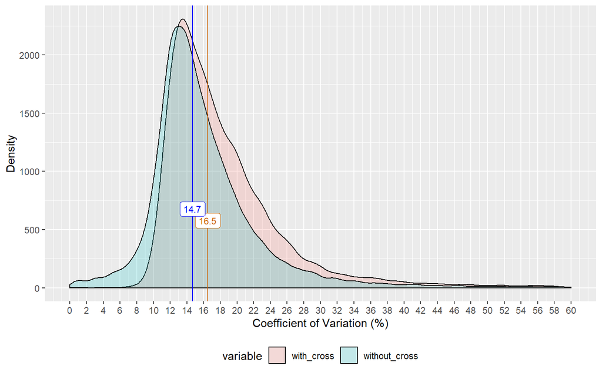

```r
#
# Plot CV distribution
#
cvs = reshape2::melt(background.ions$CVs)
median.cross = median(background.ions$CVs$with_cross, na.rm = TRUE)
median.nocross = median(background.ions$CVs$without_cross, na.rm = TRUE)

p = ggplot(data = cvs, aes(x = value, fill = variable)) + geom_density(aes(y=..count..), alpha = 0.2) +
  geom_vline(xintercept = median.cross, col = "darkorange3") +
  geom_vline(xintercept = median.nocross, col = "blue") +
  scale_x_continuous(breaks = seq(0, 60, by = 2), limits = c(0,60)) +
  labs( x = "Coefficient of Variation (%)", y = "Density")

p.data <- ggplot_build(p)$data[[1]]
p.groups <- lapply(split(p.data, f = p.data$group), function(df){
  df[which.max(df$count), ]
})

p +
  annotate(geom= "label", label = sprintf("%1.1f", median.cross), x = median.cross,y = p.groups[[1]]$count/4 , size = 3, col = "darkorange3") +
  annotate(geom= "label", label = sprintf("%1.1f", median.nocross), x = median.nocross, y = p.groups[[1]]$count/4+100, size = 3, col = "blue") +
  theme(legend.position = "bottom")
```

## Peptides analysis

### Peptides Summary

Summary of identified and quantified (fully or partially) peptides, grouped by matching accessions categories (see `flags_accession_regexp` parameter).

```r
peptides_summary = quantified_summary(proline.peptides, params$abundance_column_regexp)

## add the file summary to the global one
peptides_count_summary = peptides_summary$counts
peptides_count_summary$file = file
peptides.summary = rbind(peptides.summary, peptides_count_summary)
```

```r
knitr::kable(peptides_summary$counts)
```

| name | background | ups | unknown | total |
| --- | --- | --- | --- | --- |
| all | 20499 | 723 | 178 | 21400 |
| not_quantified | 127 | 3 | 1 | 131 |
| quantified | 20372 | 720 | 177 | 21269 |
| fully_quantified | 11660 | 14 | 89 | 11763 |
| partially_quantified | 8712 | 706 | 88 | 9506 |
| missing_values | 78650 | 15025 | 1435 | 95110 |
| expected_values | 814880 | 28800 | 7080 | 850760 |

```r
knitr::kable(peptides_summary$rates)
```

| name | background | ups | unknown | total |
| --- | --- | --- | --- | --- |
| missing_value_rate | 9.651728 | 52.17014 | 20.26836 | 11.17942 |

### peptides Missing values

Number of peptides matching a “background” (see `flags_accession_regexp` parameter, if “background” category is undefined, takes all peptides into account) protein for which an abundance value was defined in more than *n* samples.

[figure not shown]

```r
ggplot(background.peptides$missing,aes(runs_count, y = value, color = variable)) +
  geom_point(aes(y = with_cross, col = 'with cross-assignment'), size = 3) +
  geom_point(aes(y = without_cross, col = 'without cross-assignment'), size = 3) +
  ylim(0, NA) + labs(title = "Background peptides quantifed in at least x runs ", x = "# runs", y = "# peptides") +
  theme(legend.position = "bottom")
```

### peptides CVs distribution

peptides CVs distribution with/without cross-assigned values.

```r
cvs_summary = rbind( nocross = summary(na.omit(background.peptides$CVs$without_cross)),
                     cross = summary(na.omit(background.peptides$CVs$with_cross)))
knitr::kable(cvs_summary)
```

|  | Min. | 1st Qu. | Median | Mean | 3rd Qu. | Max. |
| --- | --- | --- | --- | --- | --- | --- |
| nocross | 0.0931252 | 12.15035 | 14.47463 | 16.51379 | 18.04631 | 365.4676 |
| cross | 4.3837497 | 13.46401 | 16.17754 | 18.94684 | 20.62624 | 365.4676 |

peptides CVs density plot.

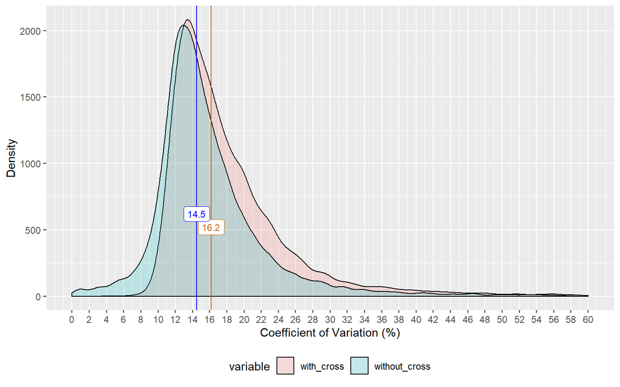

```r
#
# Plot CV distribution
#
cvs = reshape2::melt(background.peptides$CVs)
median.cross = median(background.peptides$CVs$with_cross, na.rm = TRUE)
median.nocross = median(background.peptides$CVs$without_cross, na.rm = TRUE)

p = ggplot(data = cvs, aes(x = value, fill = variable)) + geom_density(aes(y=..count..), alpha = 0.2) +
  geom_vline(xintercept = median.cross, col = "darkorange3") +
  geom_vline(xintercept = median.nocross, col = "blue") +
  scale_x_continuous(breaks = seq(0, 60, by = 2), limits = c(0, 60)) +
  labs(x = "Coefficient of Variation (%)", y = "Density")

p.data <- ggplot_build(p)$data[[1]]
p.groups <- lapply(split(p.data, f = p.data$group), function(df){
  df[which.max(df$count), ]
})

p +
  annotate(geom = "label", label = sprintf("%1.1f", median.cross), x = median.cross, y = p.groups[[1]]$count/4,size = 3,col = "darkorange3") +
  annotate(geom = "label", label = sprintf("%1.1f", median.nocross),x = median.nocross,y = p.groups[[1]]$count/4 + 100,size = 3,col = "blue") +
  theme(legend.position = "bottom")
```

## Proteins analysis

The data are read from the proteins sheet of the analyzed Excel file. **Contaminant are filtered**

```r
proline.proteins = openxlsx::read.xlsx(filename, sheet = params$proteins_sheet_index, colNames = TRUE, startRow = 0)
proline.proteins = dplyr::select(proline.proteins, matches(paste0('accession|', params$abundance_column_regexp)))
proline.proteins = proline.proteins %>% filter(!grepl("^#C#", accession))
proline.proteins = flag_by_accession(proline.proteins, params$flags_accession_regexp)
proline.proteins = replace_zero_by_na(proline.proteins, params$abundance_column_regexp)
```

### Proteins Summary

```r
proteins_summary = quantified_summary(proline.proteins, params$abundance_column_regexp)
knitr::kable(proteins_summary$counts)
```

| name | background | ups | total |
| --- | --- | --- | --- |
| all | 2888 | 48 | 2936 |
| not_quantified | 29 | NA | 29 |
| quantified | 2859 | 48 | 2907 |
| fully_quantified | 2271 | 15 | 2286 |
| partially_quantified | 588 | 33 | 621 |
| missing_values | 5604 | 259 | 5863 |
| expected_values | 114360 | 1920 | 116280 |

```r
knitr::kable(proteins_summary$rates)
```

| name | background | ups | total |
| --- | --- | --- | --- |
| missing_value_rate | 4.900315 | 13.48958 | 5.04214 |

```r
proteins_summary = proteins_summary$counts
proteins_summary$file = file
proteins.summary = rbind(proteins.summary, proteins_summary)
```

### Proteins CVs distribution

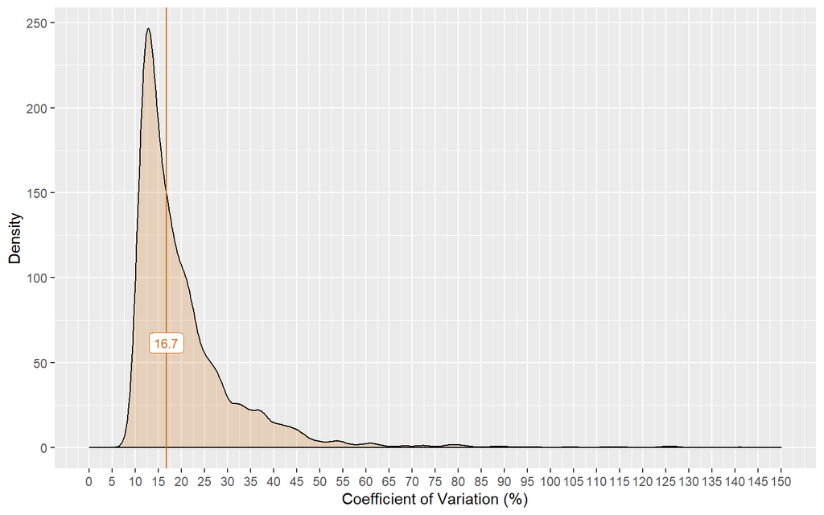

```r
background.proteins = abundance_values_analysis(proline.proteins, background_accession_regexp, params$abundance_column_regexp)

median.cv = median(background.proteins$CVs, na.rm = TRUE)

p = ggplot(data = data.frame(cv=background.proteins$CVs), aes(x = cv)) + geom_density(aes(y=..count..), alpha = 0.2, fill = "darkorange3") +
  geom_vline(xintercept = median.cv, col = "darkorange3") +
  scale_x_continuous(breaks = seq(0, 150, by = 5), limits = c(0,150)) +
  labs( x = "Coefficient of Variation (%)", y = "Density")

p.data <- ggplot_build(p)$data[[1]]
p.groups <- lapply(split(p.data, f = p.data$group), function(df){
  df[which.max(df$count), ]
})

p +
  annotate(geom= "label", label = sprintf("%1.1f", median.cv), x = median.cv, y = p.groups[[1]]$count/4, size = 3, col = "darkorange3") +
  theme(legend.position = "bottom")
```

```r
condition = gsub(".*_(.*)\\.xlsx", "\\1", file)
if (condition == file) {
  condition = gsub("(.*)\\.xlsx", "\\1", file)
}
apply_diff_analysis = grepl('-', condition) && is.element("dapar_test_method", names(params))
```

```r
  cat('### Proteins differential analysis')
```

```r
r = dapar_differential_protein_analysis(proline.proteins,
                                      condition,
                                      params$abundance_column_regexp,
                                      params$dapar_normalize,
                                      params$dapar_imputation,
                                      params$dapar_quantile_qval,
                                      params$dapar_test_method)

all.proteins = rbind(all.proteins, r)

ggplot(r, aes(x = logFC, y = -log10(pvalue))) +
  geom_point(aes(color = factor(flag)), size = 3.5, shape = 16, alpha = .6) +
  scale_x_continuous(breaks = seq(-9, 9, by = 1), limits = c(-9,9)) +
  theme(legend.position = "bottom")
```

Intensities distribution

```r
ma.proteins = all.proteins %>% mutate(C1_mean = rowMeans(select(., starts_with("C1")), na.rm = TRUE))
ggplot(ma.proteins) + geom_point(aes(x = log10(C1_mean), y = logFC, color = flag), shape = 16, alpha = .6)
```

# Expected vs Observed Ratios

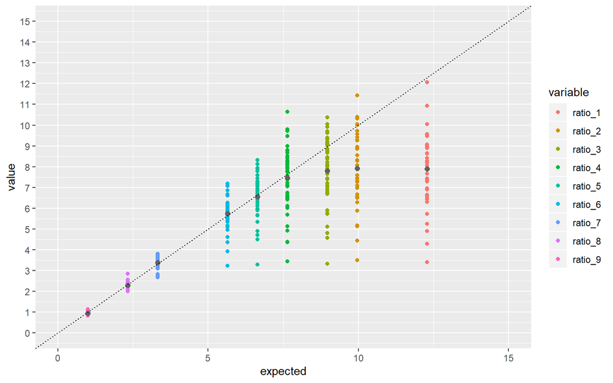

```r
conditions = c("10amol", "50amol", "100amol", "250amol", "500amol", "1fmol", "5fmol", "10fmol", "25fmol", "50fmol")
columns = group_columns_by_conditions(proline.proteins, conditions , params$abundance_column_regexp)
column.other.indexes = which(!(colnames(proline.proteins) %in% list.flatten(columns)))

ups.proteins = proline.proteins[which(proline.proteins$flag == 'ups'),]

ratios = ratios_analysis(ups.proteins, columns)
ups.ratios = select(ratios, "accession", starts_with("ratio"))

library(reshape2)
ups.ratios.melted = melt(ups.ratios, id.vars="accession")
means = ups.ratios.melted %>% group_by(variable) %>% summarize(mean_observed = mean(value, na.rm = TRUE))

expected = c(12.28771238,9.965784285,8.965784285,7.64385619,6.64385619,5.64385619,3.321928095,2.321928095,1)
means = cbind(means, expected)
ups.ratios.melted$expected = rep(expected, each = 48)

ggplot(ups.ratios.melted, aes(x = expected, y = value, colour = variable )) +
  geom_point() +
  geom_point(data = means, aes(x = expected, y = mean_observed), size = 2, color = "gray38") +
  geom_abline(intercept =0 , slope = 1, linetype = "12") +
  xlim(0,15) +
  scale_y_continuous(breaks = seq(0, 15, by = 1), limits = c(0,15))
```

Christophe Bruley

2020-02-05